# Adding a Dark Cloud of Smoke

After the initial burst of fire, our explosion should turn into a dark smoke cloud.

That’s what we are going to create in this lesson.

[video not shown]

## Setting up the smoke cloud

Create a new *Particles2D* as a child of the *Explosion* node and name it *SmokeCloudParticles2D*. Place the *SmokeCloudParticles2D* above *FireBurstParticles2D* in the *SceneTree*, so the smoke appears behind the fire. Godot renders nodes in their tree order from top to bottom unless you change their *Z Index*.

Increase the emission *Amount* to `16` and the *Lifetime* property to `3.0` so the smoke slowly dissipates in the air.

Since the smoke follows the fire burst, we want it to start big already. Set both *Preprocess* and *Explosiveness* to `0.6`, to make the smoke cloud denser.

To ensure the particles move independently from the node, toggle off *Local Coordinates*.

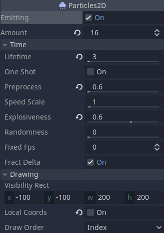

Finally, we’re going to use the same texture we used in the fire particles. Assign *puff.png* to the smoke node’s *Texture*.

## Making the cloud spread slowly

Let’s make the particles spread in all directions as we did with the fire burst.

Create a new *ParticlesMaterial* in the *Material* property and expand the resource.

Set the *Direction > Spread* property to `180`. To prevent the particles from falling set all values in the *Gravity* category to `0.0`. Expand the *Initial Velocity* category and set the *Velocity* to `80` so the particles move at a slow speed. Randomize the motion by setting *Velocity Random* to `0.6`.

Let’s increase the emission area to spread the puffs even more. Change the *Emission Shape > Shape* property from “Point” to “Sphere” and increase the *Sphere Radius* to `40`.

To make the cloud feel alive, let’s make the puffs rotate a bit. Set the *Angular Velocity > Velocity* to `40`.

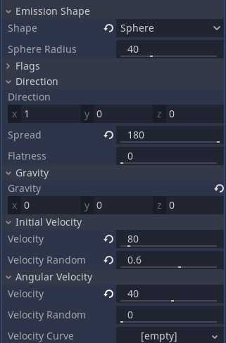

As we did in the previous part, let’s also add damping to the particles so they slow down as they spread. Set *Damping > Damping* to `40` and the *Damping Randomness* to `0.5`.

We’ll also have each particle start with a random rotation. Set *Angle > Angle* to `360` and *Angle Randomness* to `1.0`. This will asign each particle a random rotation between 0 and 360 degrees.

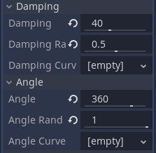

## Fading smoke

As the cloud grows larger, it should decelerate and fade out.

Next, we need to make the cloud grow. Set *Scale > Scale* to `2.6` to increase the maximum size of each particle. To add some variation to their size, drag the *Scale > Scale Random* slider to about `0.5`.

Create a new “CurveTexture” in the *Scale > Scale Curve* property. We’re going to create a plateau-shaped curve. The particles will increase in size, maintain their final scale for a while, then shrink to about half their maximum scale.

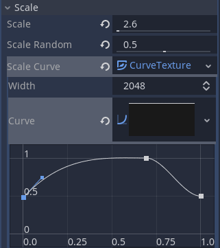

Finally, to fade the smoke, create a new Gradient in the *Color > Color Ramp* property like we did in the previous chapter. The smoke cloud should go from a brownish-gray to a darker tone and quickly fade out.

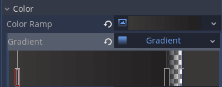

In the next part we’re going to see how to create fire trails.